# Code Notebook for Lecture 10

## Analysis for Built-in Dataset `mtcars`

We load the dataset

```r
data(mtcars)
head(mtcars)
```

|  | mpg | cyl | disp | hp | drat | wt | qsec | vs | am | gear | carb |
| --- | --- | --- | --- | --- | --- | --- | --- | --- | --- | --- | --- |
| Mazda RX4 | 21.0 | 6 | 160 | 110 | 3.90 | 2.620 | 16.46 | 0 | 1 | 4 | 4 |
| Mazda RX4 Wag | 21.0 | 6 | 160 | 110 | 3.90 | 2.875 | 17.02 | 0 | 1 | 4 | 4 |
| Datsun 710 | 22.8 | 4 | 108 | 93 | 3.85 | 2.320 | 18.61 | 1 | 1 | 4 | 1 |
| Hornet 4 Drive | 21.4 | 6 | 258 | 110 | 3.08 | 3.215 | 19.44 | 1 | 0 | 3 | 1 |
| Hornet Sportabout | 18.7 | 8 | 360 | 175 | 3.15 | 3.440 | 17.02 | 0 | 0 | 3 | 2 |
| Valiant | 18.1 | 6 | 225 | 105 | 2.76 | 3.460 | 20.22 | 1 | 0 | 3 | 1 |

Suppose we consider a linear regression of `mpg` against `disp`. We first check the scatter plot.

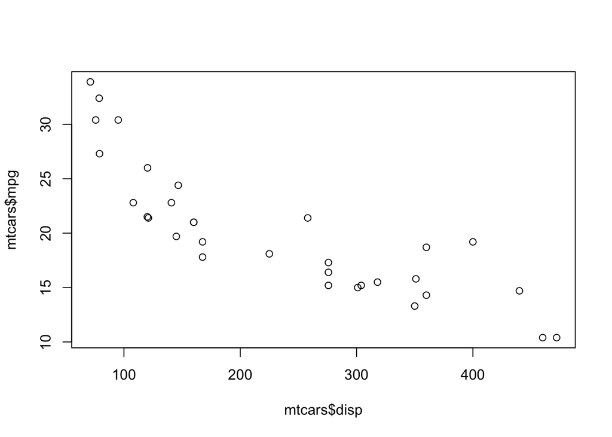

```r
plot(mtcars$disp, mtcars$mpg)
```

It shows a nonlinear trend. So we create two new columns by taking the log.

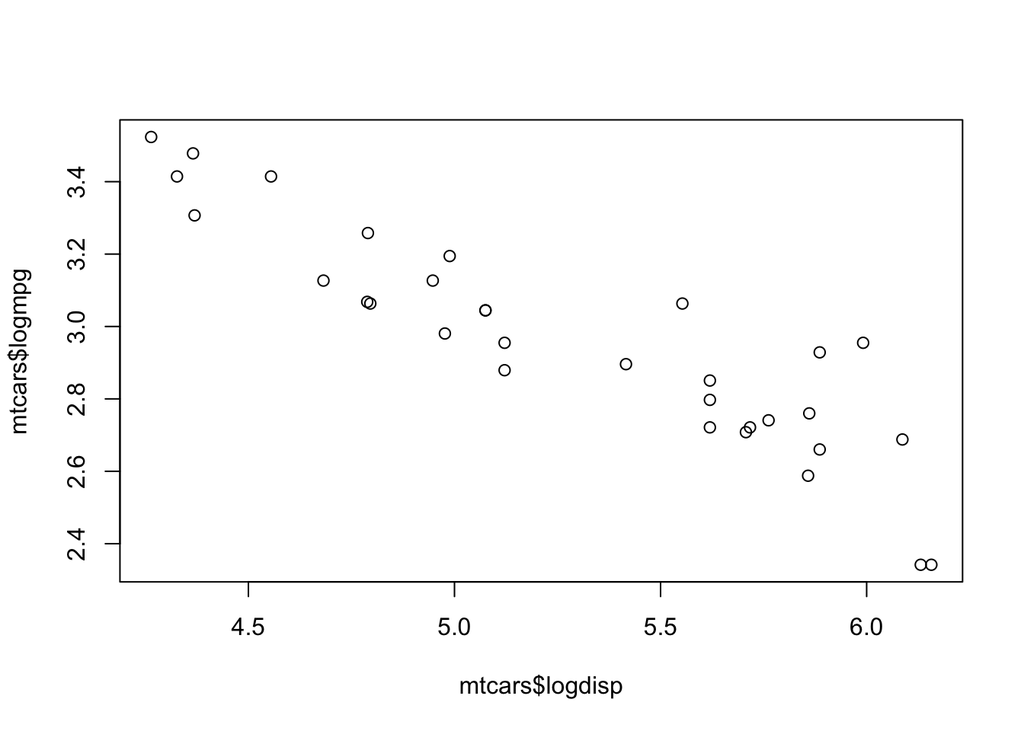

```r
mtcars['logmpg'] = log(mtcars$mpg)
mtcars['logdisp'] = log(mtcars$disp)
plot(mtcars$logdisp, mtcars$logmpg)
```

Now the trend is linear. We run a linear regression model.

```r
fit = lm(logmpg ~ logdisp, data=mtcars)
print(summary(fit))
```

```
##
## Call:
## lm(formula = logmpg ~ logdisp, data = mtcars)
##
## Residuals:
##      Min       1Q   Median       3Q      Max
## -0.22758 -0.08874 -0.00791  0.07970  0.32143
##
## Coefficients:
##             Estimate Std. Error t value Pr(>|t|)
## (Intercept)  5.38097    0.20803   25.87  < 2e-16 ***
## logdisp     -0.45857    0.03913  -11.72 1.01e-12 ***
## ---
## Signif. codes:  0 '***' 0.001 '**' 0.01 '*' 0.05 '.' 0.1 ' ' 1
##
## Residual standard error: 0.1282 on 30 degrees of freedom
## Multiple R-squared:  0.8207, Adjusted R-squared:  0.8148
## F-statistic: 137.3 on 1 and 30 DF,  p-value: 1.006e-12
```

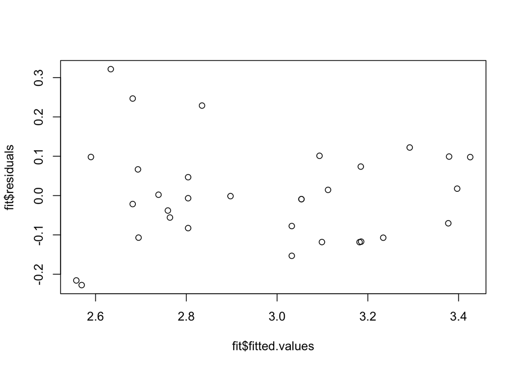

```r
plot(fit$fitted.values, fit$residuals)
```

The residual plot is not too bad, though some unequal variances.

Then we check the QQ-plot.

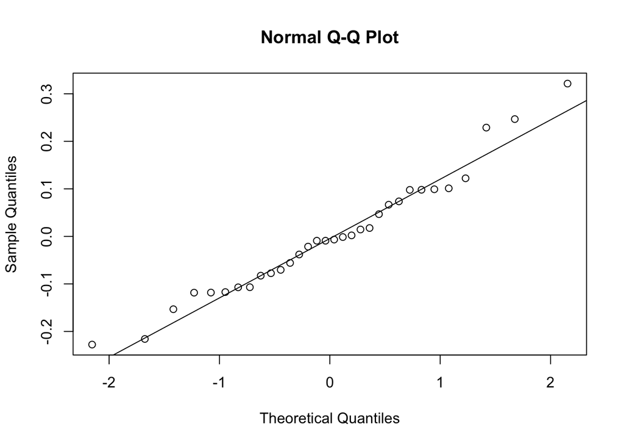

```r
qqnorm(fit$residuals)
qqline(fit$residuals)
```

The QQ-plot indicates the residuals are normal.

Or we can call `plot` directly.

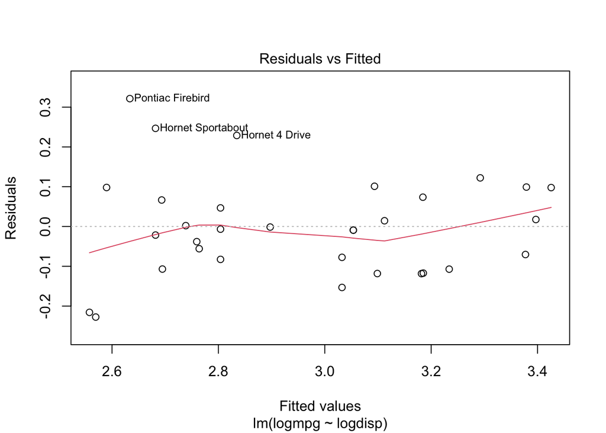

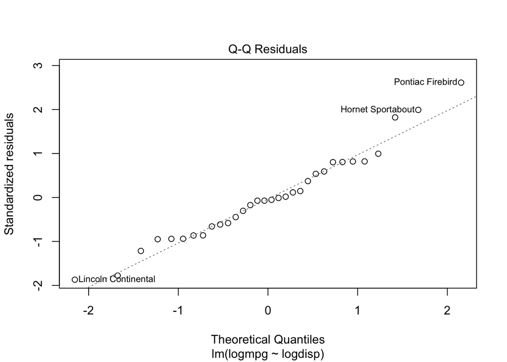

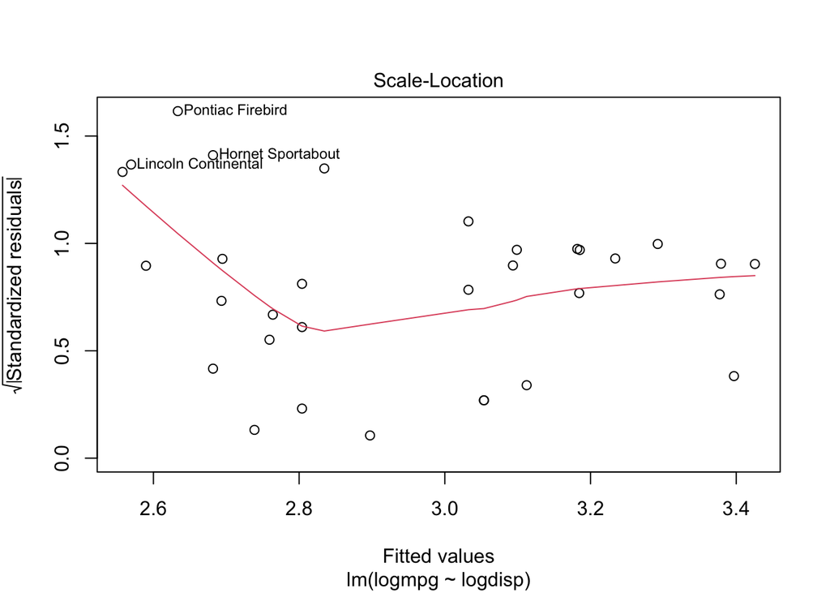

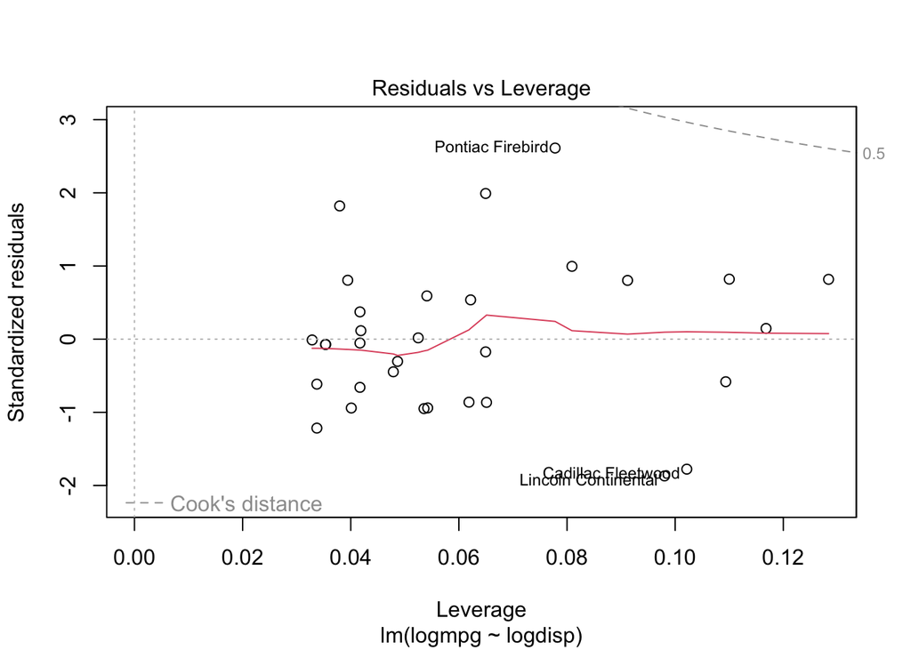

```r
plot(fit)
```

## Prediction

Suppose there is a new car with `disp`=300. The prediction is

```r
pred = predict(fit, newdata = data.frame(logdisp=log(300)))
print(pred)
```

```
##        1
## 2.765399
```

The predicted value for the `logmpg` is 2.765.

The confidence interval for the mean response is

```r
ci = predict(fit, newdata = data.frame(logdisp=log(300)), interval="confidence")
print(ci)
```

```
##        fit      lwr      upr
## 1 2.765399 2.708287 2.822511
```

The CI for the mean response of `logmpg` is (2.708, 2.823).

The prediction interval is

```r
pi = predict(fit, newdata = data.frame(logdisp=log(300)), interval="prediction")
print(pi)
```

```
##        fit      lwr      upr
## 1 2.765399 2.497496 3.033301
```

The PI for `logmpg` is (2.497, 3.033).

We can print the CI band and PI band.

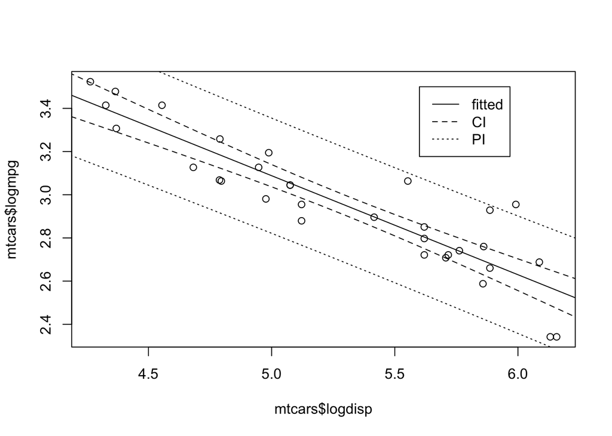

```r
newx = seq(4, 6.5, 0.1)
ci.band = predict(fit, newdata = data.frame(logdisp=newx), interval="confidence")
pi.band = predict(fit, newdata = data.frame(logdisp=newx), interval="prediction")
plot(mtcars$logdisp, mtcars$logmpg)
lines(newx, ci.band[,'fit'], type='l')
lines(newx, ci.band[,'upr'], type='l', lty='dashed')
lines(newx, ci.band[,'lwr'], type='l', lty='dashed')
lines(newx, pi.band[,'upr'], type='l', lty='dotted')
lines(newx, pi.band[,'lwr'], type='l', lty='dotted')
legend(5.6, 3.5,lty=c("solid", "dashed", "dotted"), legend=c("fitted", "CI", "PI"))
```

We can also compare the pointwise CI v.s. simultaneous CI.

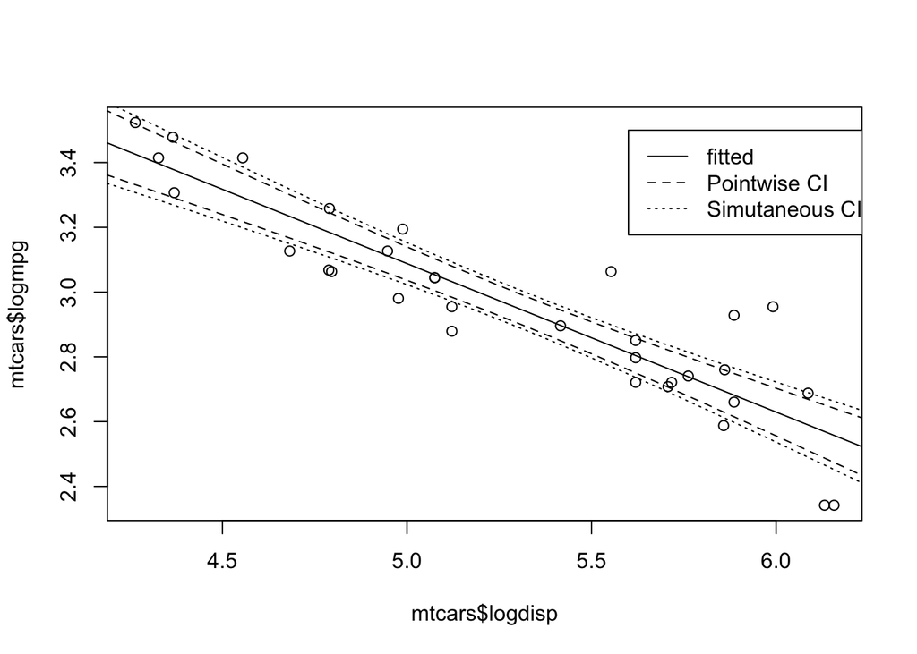

```r
n = dim(mtcars)[1]
Sxx = var(mtcars$logdisp) * (n-1)
xbar = mean(mtcars$logdisp)
sci.lwr = ci.band[,'fit'] - sqrt(2*qf(0.95,2,fit$df.residual)) * summary(fit)$sigma * sqrt(1/n + (newx - xbar) ** 2 /Sxx)
sci.upr = ci.band[,'fit'] + sqrt(2*qf(0.95,2,fit$df.residual)) * summary(fit)$sigma * sqrt(1/n + (newx - xbar) ** 2 /Sxx)

plot(mtcars$logdisp, mtcars$logmpg)
lines(newx, ci.band[,'fit'], type='l')
lines(newx, ci.band[,'upr'], type='l', lty='dashed')
lines(newx, ci.band[,'lwr'], type='l', lty='dashed')
lines(newx, sci.upr, type='l', lty='dotted')
lines(newx, sci.lwr, type='l', lty='dotted')
legend(5.6, 3.5,lty=c("solid", "dashed", "dotted"), legend=c("fitted", "Pointwise CI", "Simutaneous CI"))
```